# project

Jingjing Dong

2024-12-10

## Project Description

The extent to which medication and talk are linearly associated with lifetime anxiety and depression.

Data is available from this link:

https://ourworldindata.org/grapher/share-who-report-lifetime-anxiety-or-depression.csv?v=1&csvType=full&useColumnShortNames=true

https://ourworldindata.org/grapher/dealt-with-anxiety-depression-took-prescribed-medication.csv?v=1&csvType=full&useColumnShortNames=true

https://ourworldindata.org/grapher/dealt-with-anxiety-depression-friends-family.csv?v=1&csvType=full&useColumnShortNames=true

https://ourworldindata.org/grapher/stand-alone-policy-or-plan-for-mental-health.csv?v=1&csvType=full&useColumnShortNames=true

The URL for these pages is:

https://jean-dj.github.io/PSY6422.project.JD/

The repository for these pages is:

https://github.com/Jean-DJ/PSY6422.project.JD

## Import data

```r
lifetime_ = "https://ourworldindata.org/grapher/share-who-report-lifetime-anxiety-or-depression.csv?v=1&csvType=full&useColumnShortNames=true"
medication_ = "https://ourworldindata.org/grapher/dealt-with-anxiety-depression-took-prescribed-medication.csv?v=1&csvType=full&useColumnShortNames=true"
talking_ = "https://ourworldindata.org/grapher/dealt-with-anxiety-depression-friends-family.csv?v=1&csvType=full&useColumnShortNames=true"
policy_ = "https://ourworldindata.org/grapher/stand-alone-policy-or-plan-for-mental-health.csv?v=1&csvType=full&useColumnShortNames=true"

# import data file as csv
dat_l <- read.csv(lifetime_)
dat_m <- read.csv(medication_)
dat_t <- read.csv(talking_)
dat_p <- read.csv(policy_)
```

## Wrangle Data

Merge the four files. processing redundant data. Extracting usable data

```r
# Read R package
library(tidyverse)

# Merge data from different files by Entity
dat_lm <- left_join(dat_l, dat_m, by = "Entity")
dat_lmt <- left_join(dat_lm, dat_t, by = "Entity")
dat <-left_join(dat_lmt, dat_p, by = "Entity")

# omit rows with NA in any column of data frame
dat <- na.omit (dat)

# Simplification of columns
dat <- dat %>%
  rename(code = Code.x, year = Year.x, lifetime = share__question_mh7a__have_been_anxious_depressed__answer_yes__gender_all__age_group_all, medication = share__question_mh8d__took_prescribed_medication_when_anxious_depressed__answer_yes__gender_all__age_group_all, talking = share__question_mh8c__talked_to_friends_or_family_when_anxious_depressed__answer_yes__gender_all__age_group_all, policy = stand_alone_policy_or_plan_for_mental_health)

# Removing duplicates
dat <- dat[!duplicated(dat$Entity),]
dat <- dat %>% select(-Code.y, -Year.y, -Code.x.x, -Year.x.x, -Code.y.y, -Year.y.y)
```

## Visualise the data

Draw a scatter plot and a line for the degree of linear correlation

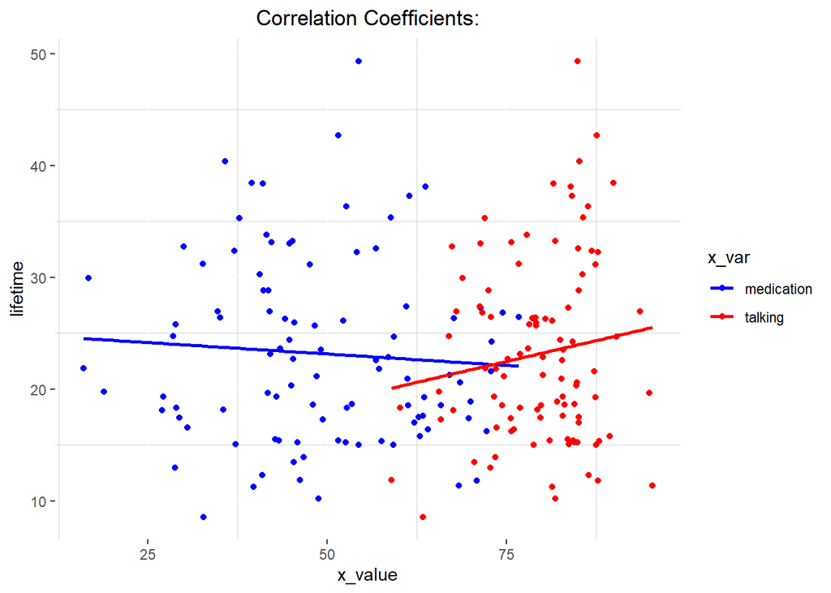

```r
# Calculate correlation coefficients for each pair (medication ~ lifetime and talking ~ lifetime)
correlation1 <- cor(dat$medication, dat$lifetime)
correlation2 <- cor(dat$talking, dat$lifetime)

# Convert data to long format for ggplot
data_long <- dat %>%
    pivot_longer(cols = c(medication, talking), names_to = "x_var", values_to = "x_value")
y <- dat$lifetime

# Plot of linear correlation coefficients
# Create the scatter plot with both medication and talking against lifetime in the same plot
# The blue and red dots and lines represent medication ~ lifetime, talking ~ lifetime
library(ggplot2)
p <- ggplot(data_long, aes(x = x_value, y = lifetime, color = x_var)) +
  geom_point() +
  geom_smooth(aes(color = x_var), method = "lm", se = FALSE) +
  ggtitle(paste("Correlation Coefficients:")) +
  scale_color_manual(values = c("medication" = "blue", "talking" = "red")) +
  theme(panel.background = element_rect(fill = "white"), plot.title = element_text(hjust = 0.5),  panel.grid.minor = element_line(color = "lightgray", size = 0.25))
print(p)
```

```r
# Saving the plot to a PNG file
ggsave("plot/correlation coefficients.png", plot = p, width = 8, height = 6, dpi = 300)
```

## summary

Figure, talking ~ lifetime(red) is positively correlated, medication ~ lifetime(blue) is negatively correlated. Both are small.

## future directions

More interventions that may be helpful for anxiety and depressive disorders could be included to observe the kind of intervention that is more effective. Comparisons could also be made between interventions for lifetime depressive anxiety and all depressive anxiety.